# Malignant neoplasms of parts of central nervous system

Davide Bottoli, Przemysław Dycha, Karolina Gajewska

31 maja 2016

# Introduction

The main goal of this phase is finding and presenting the predictions for number of cancer cases in different regions of Poland. Identification of outliers. Comparision of results for different models.

# Choosing type of cancer

In order to predicting numbers of choosed cancer case we adding into our dataframe new factors, which can contribute to cancer disease.

We used data from GUS. We have choosed data about:

- normalized value of dust pollution for each subregions
- Causes of deaths - cancer general
- general population for each subregions and gender.

We also creted group of type of cancer, like this:

```r
DT_ACT_C<-load("Cancer.Rda")
DT_ACT_C
```

```
## [1] "cancer"
```

Finally, we have:

```
##   ICD10 PLEC grupa_wiek TERYT4 TERYT4a woj pow  rok Stage1 Stage2 Stage3
## 1   C00    K     <0-44>    461     461   4  61 2010    0.0    1.0    0.0
## 2   C00    K     <0-44>    601     601   6   1 2011    0.0    0.0    0.2
## 3   C00    K     <0-44>   1001    1001  10   1 2012    0.7    0.3    0.0
##   Stage4 new                                  CancerGroup CancerSex
## 1    0.0   1  Malignant neoplasms of head and neck cancer      Both
## 2    0.8   1  Malignant neoplasms of head and neck cancer      Both
## 3    0.0   1  Malignant neoplasms of head and neck cancer      Both
##                 Nazwa TERYT.ROK     ZPP   DC    LUD LUD_PLEC_R       WSP
## 1  Powiat m.Bydgoszcz   4612010 4.19886 1161 364443     192905 0.5183899
## 2      Powiat bialski   6012011 0.01125  287 114052      57540 1.7379214
## 3 Powiat bechatowski  10012012 1.43905  249 113173      57498 1.7391909
```

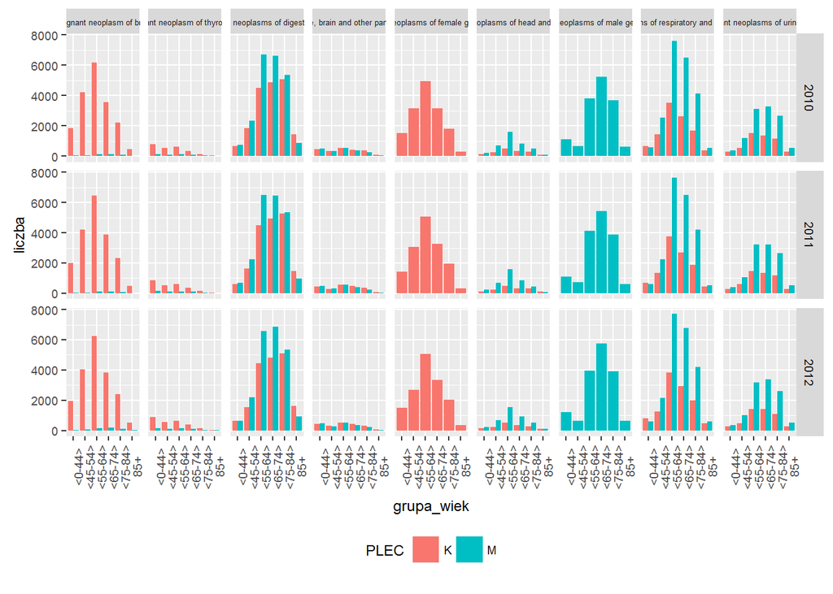

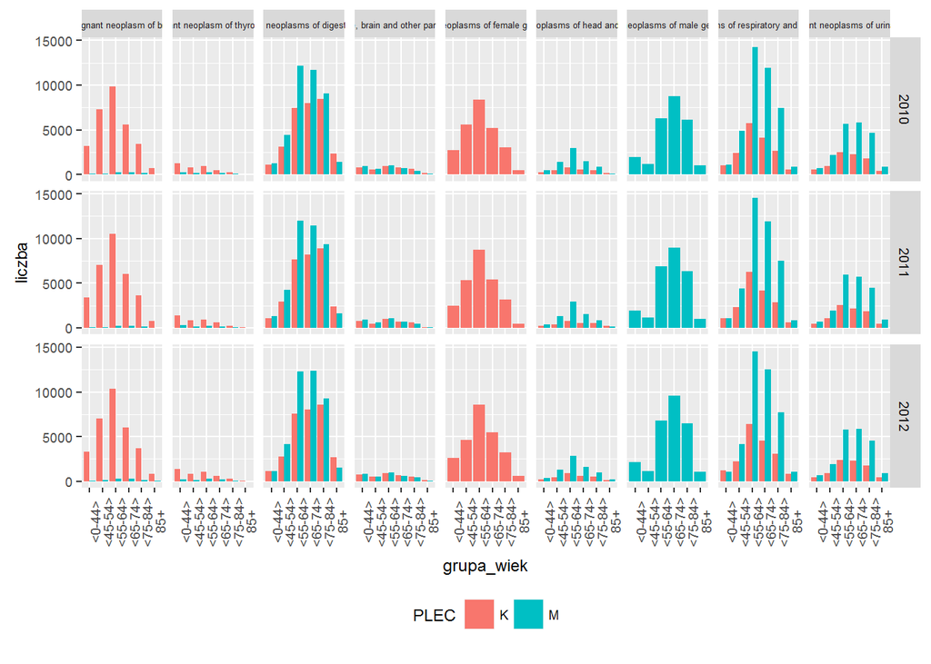

Based on the charts, we can conclude that the decomposition rate of incidence of cancer of the central nervous system are similar for both women and men, which is why we give them for further analysis.

# Linear model

Let’s start with a simple linear model:

```r
lm1 <- lm(new ~ PLEC+grupa_wiek+woj+ZPP+DC, data = DC_ACT11)
BIC(lm1)
```

```
## [1] 21316.81
```

```r
lm2 <- lm(new ~ PLEC+grupa_wiek+TERYT4+ZPP+DC, data = DC_ACT11)
BIC(lm2)
```

```
## [1] 21316.81
```

We have very similar results, so we use more detalied model with subregions. But let’s add stepwise selection:

```
## Start:  AIC=3305.16
## new ~ PLEC + grupa_wiek + woj + ZPP + DC
##
##              Df Sum of Sq   RSS    AIC
## - woj         1       0.2 10628 3303.3
## <none>                    10628 3305.2
## - ZPP         1       6.6 10635 3307.1
## - PLEC        1      25.7 10654 3318.4
## - grupa_wiek  5    1106.3 11735 3921.0
## - DC          1   15844.3 26473 9070.7
##
## Step:  AIC=3303.26
## new ~ PLEC + grupa_wiek + ZPP + DC
##
##              Df Sum of Sq   RSS    AIC
## <none>                    10628 3303.3
## - ZPP         1       6.8 10635 3305.3
## - PLEC        1      25.7 10654 3316.5
## - grupa_wiek  5    1106.1 11735 3919.0
## - DC          1   15879.0 26508 9077.0
```

```
## Start:  AIC=3305.16
## new ~ PLEC + grupa_wiek + woj + ZPP + DC
##
##              Df Sum of Sq   RSS    AIC
## - woj         1       0.2 10628 3303.3
## <none>                    10628 3305.2
## - ZPP         1       6.6 10635 3307.1
## - PLEC        1      25.7 10654 3318.4
## - grupa_wiek  5    1106.3 11735 3921.0
## - DC          1   15844.3 26473 9070.7
##
## Step:  AIC=3303.26
## new ~ PLEC + grupa_wiek + ZPP + DC
##
##              Df Sum of Sq   RSS    AIC
## <none>                    10628 3303.3
## + woj         1       0.2 10628 3305.2
## - ZPP         1       6.8 10635 3305.3
## - PLEC        1      25.7 10654 3316.5
## - grupa_wiek  5    1106.1 11735 3919.0
## - DC          1   15879.0 26508 9077.0
```

```
## Start:  AIC=3305.16
## new ~ PLEC + grupa_wiek + woj + ZPP + DC
```

```
## [1] 21240.64
```

```
## [1] 21240.64
```

```
## [1] 21242.54
```

```
## Start:  AIC=3305.16
## new ~ PLEC + grupa_wiek + TERYT4 + ZPP + DC
##
##              Df Sum of Sq   RSS    AIC
## - TERYT4      1       0.2 10628 3303.3
## <none>                    10628 3305.2
## - ZPP         1       6.5 10635 3307.0
## - PLEC        1      25.7 10654 3318.4
## - grupa_wiek  5    1106.3 11735 3921.0
## - DC          1   15854.9 26483 9073.2
##
## Step:  AIC=3303.26
## new ~ PLEC + grupa_wiek + ZPP + DC
##
##              Df Sum of Sq   RSS    AIC
## <none>                    10628 3303.3
## - ZPP         1       6.8 10635 3305.3
## - PLEC        1      25.7 10654 3316.5
## - grupa_wiek  5    1106.1 11735 3919.0
## - DC          1   15879.0 26508 9077.0
```

```
## Start:  AIC=3305.16
## new ~ PLEC + grupa_wiek + TERYT4 + ZPP + DC
##
##              Df Sum of Sq   RSS    AIC
## - TERYT4      1       0.2 10628 3303.3
## <none>                    10628 3305.2
## - ZPP         1       6.5 10635 3307.0
## - PLEC        1      25.7 10654 3318.4
## - grupa_wiek  5    1106.3 11735 3921.0
## - DC          1   15854.9 26483 9073.2
##
## Step:  AIC=3303.26
## new ~ PLEC + grupa_wiek + ZPP + DC
##
##              Df Sum of Sq   RSS    AIC
## <none>                    10628 3303.3
## + TERYT4      1       0.2 10628 3305.2
## - ZPP         1       6.8 10635 3305.3
## - PLEC        1      25.7 10654 3316.5
## - grupa_wiek  5    1106.1 11735 3919.0
## - DC          1   15879.0 26508 9077.0
```

```
## Start:  AIC=3305.16
## new ~ PLEC + grupa_wiek + TERYT4 + ZPP + DC
```

```
## [1] 21240.64
```

```
## [1] 21240.64
```

```
## [1] 21242.55
```

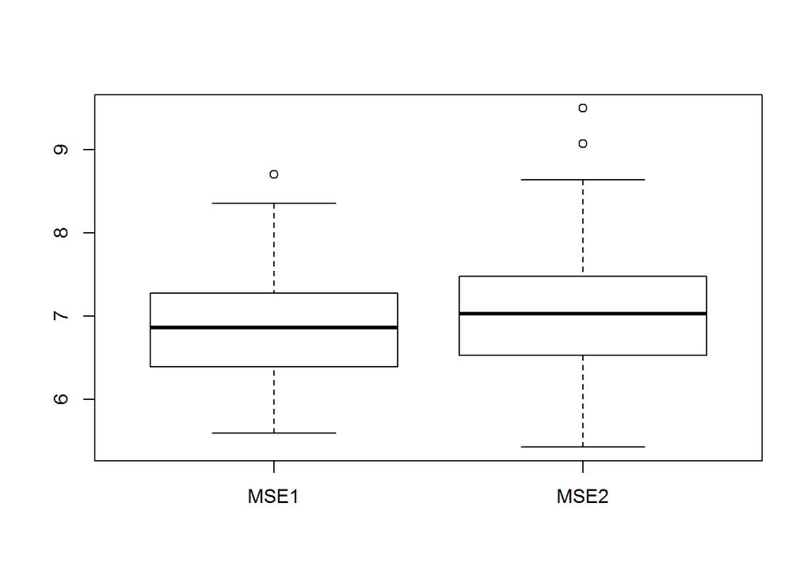

```r
boxplot(cbind(MSE1, MSE2))
```

```r
ks.test(MSE1, MSE2)
```

```
##
##  Two-sample Kolmogorov-Smirnov test
##
## data:  MSE1 and MSE2
## D = 0.12, p-value = 0.4676
## alternative hypothesis: two-sided
```

Let’s continue this patch trying to use Lasso and Ridge

```r
library(glmnet)

#RIDGE1
grid <- 10 ^ seq(10, -2, length = 100)
ridge.mod1 <- glmnet(x_1, y, family = "poisson", alpha = 0,  lambda = grid)
#str(ridge.mod1)

set.seed(1)
train = sample(1:nrow(x_1), round(0.75*nrow(x_1)))
test <- -train
y.test <- y[test]

ridge.mod1<- glmnet(x_1[train,], y[train], alpha = 0, lambda = grid, thresh = 1e-12)
ridge.pred1 <- predict(ridge.mod1, s = 2, newx = x_1[test,])
mean((ridge.pred1 - y.test)^2)
```

```
## [1] 2.039263
```

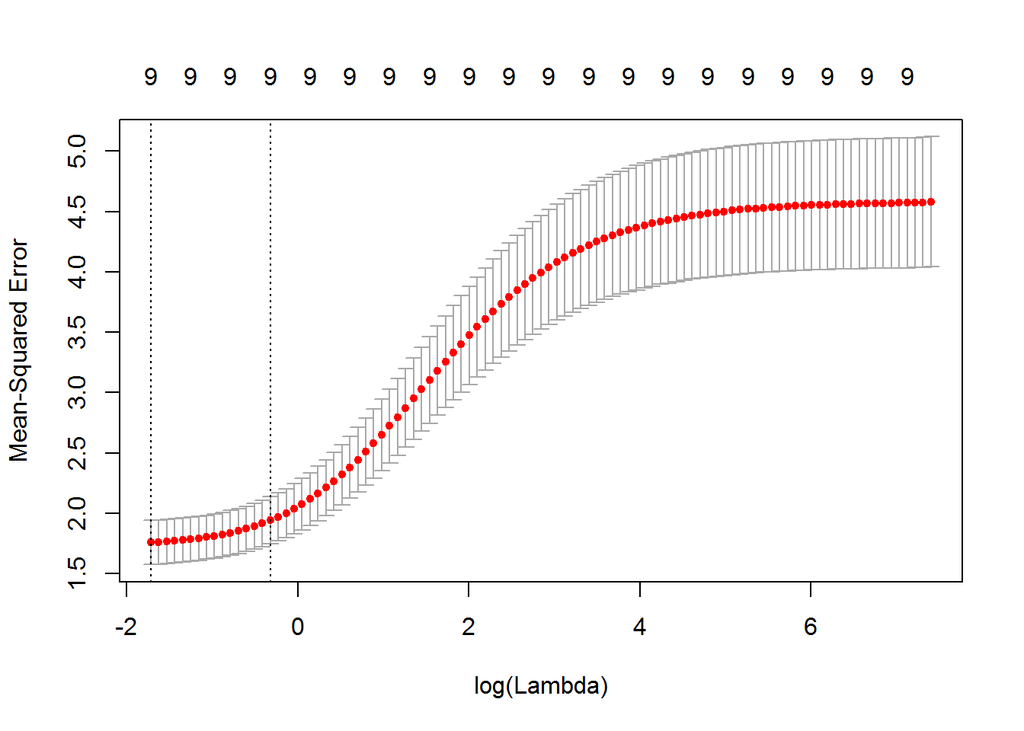

```r
cv.out1 <- cv.glmnet(x_1[train,], y[train], alpha = 0)
plot(cv.out1)
```

```r
bestlam1 <- cv.out1$lambda.min
bestlam1
```

```
## [1] 0.1799724
```

```r
ridge.pred1 <- predict(ridge.mod1, s = bestlam1, newx = x_1[test,])
mean((ridge.pred1 - y.test)^2)
```

```
## [1] 1.606999
```

```r
out1 <- glmnet(x_1, y, alpha = 0)
#predict(out1, type = "coefficients", s = bestlam1)

#RIDGE2
grid <- 10 ^ seq(10, -2, length = 100)
ridge.mod2 <- glmnet(x_2, y, alpha = 0,  lambda = grid)
#str(ridge.mod2)


set.seed(1)
train = sample(1:nrow(x_2), round(0.75*nrow(x_2)))
test <- -train
y.test <- y[test]

ridge.mod2<- glmnet(x_2[train,], y[train], alpha = 0, lambda = grid, thresh = 1e-12)
ridge.pred2 <- predict(ridge.mod2, s = 2, newx = x_2[test,])
mean((ridge.pred2 - y.test)^2)
```

```
## [1] 2.039097
```

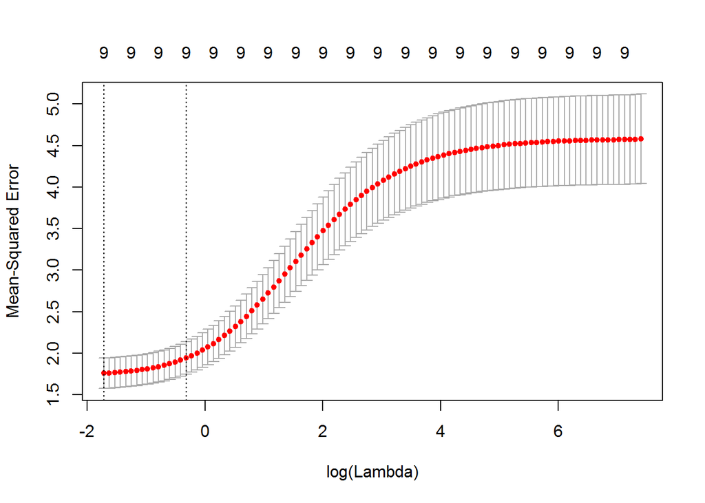

```r
cv.out2 <- cv.glmnet(x_2[train,], y[train], alpha = 0)
plot(cv.out2)
```

```r
bestlam2 <- cv.out2$lambda.min
bestlam2
```

```
## [1] 0.1799724
```

```r
ridge.pred2 <- predict(ridge.mod2, s = bestlam2, newx = x_2[test,])
mean((ridge.pred2 - y.test)^2)
```

```
## [1] 1.607003
```

```r
out2 <- glmnet(x_2, y, alpha = 0)
predict(out2, type = "coefficients", s = bestlam2)
```

```
## 10 x 1 sparse Matrix of class "dgCMatrix"
##                               1
## (Intercept)         0.999857237
## PLECM              -0.110636748
## grupa_wiek <45-54> -0.375497580
## grupa_wiek <55-64>  0.236052983
## grupa_wiek <65-74> -0.000248749
## grupa_wiek <75-84> -0.334582166
## grupa_wiek 85+     -1.435104250
## woj                -0.001036105
## ZPP                -0.003638118
## DC                  0.003227755
```

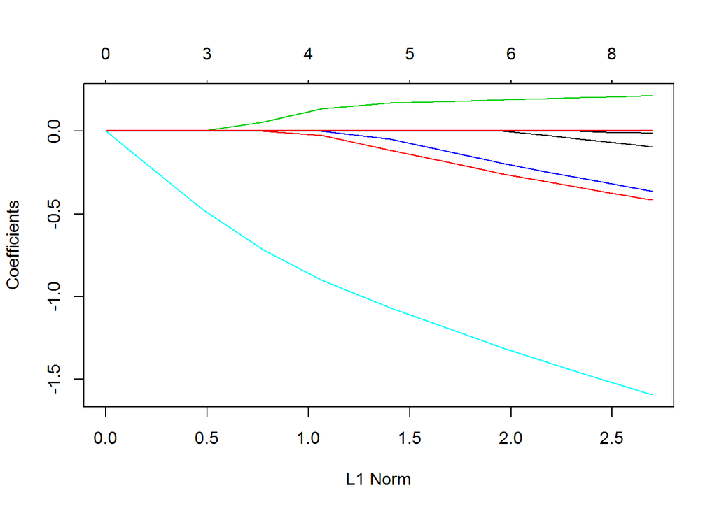

```r
#LASSO1
lasso.mod1 <- glmnet(x_1[train,], y[train], alpha = 1, lambda = grid)
plot(lasso.mod1)
```

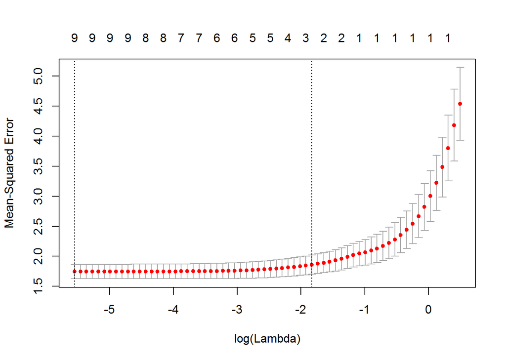

```r
cv.out3 <- cv.glmnet(x_1[train,], y[train], alpha = 1)
plot(cv.out3)
```

```r
bestlam3 <- cv.out3$lambda.min
lasso.pred1 <- predict(lasso.mod1, s = bestlam3, newx = x_1[test,])
mean((lasso.pred1 - y.test)^2)
```

```
## [1] 1.610466
```

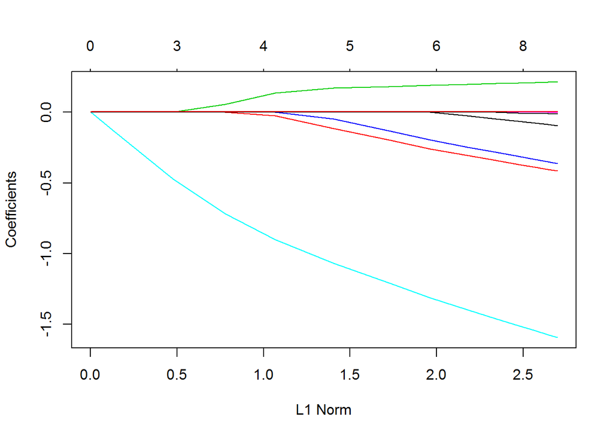

```r
out3 <- glmnet(x_1, y, alpha = 1, lambda = grid)
#predict(out3, type = "coefficients", s = bestlam3)

#LASSO2
lasso.mod2 <- glmnet(x_2[train,], y[train], alpha = 1, lambda = grid)
plot(lasso.mod2)
```

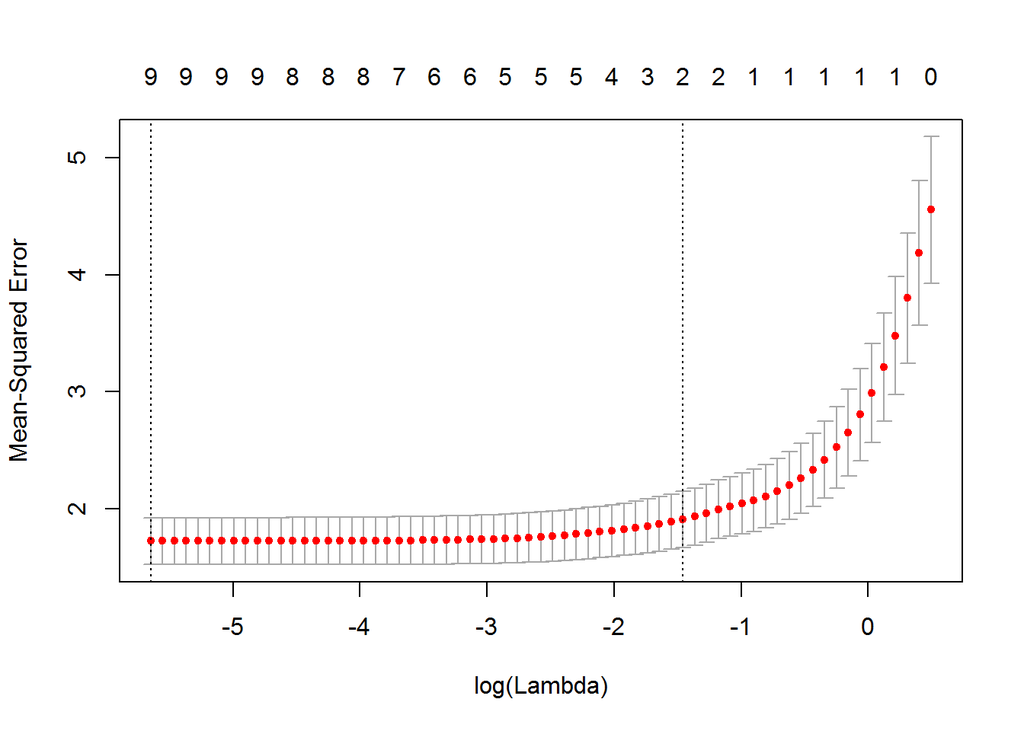

```r
cv.out4 <- cv.glmnet(x_2[train,], y[train], alpha = 1)
plot(cv.out4)
```

```r
bestlam4 <- cv.out4$lambda.min
lasso.pred2 <- predict(lasso.mod2, s = bestlam3, newx = x_2[test,])
mean((lasso.pred2 - y.test)^2)
```

```
## [1] 1.61042
```

```r
out4 <- glmnet(x_2, y, alpha = 1, lambda = grid)
predict(out4, type = "coefficients", s = bestlam4)
```

```
## 10 x 1 sparse Matrix of class "dgCMatrix"
##                               1
## (Intercept)         0.910431263
## PLECM              -0.104988029
## grupa_wiek <45-54> -0.397990758
## grupa_wiek <55-64>  0.225627224
## grupa_wiek <65-74>  .
## grupa_wiek <75-84> -0.355113367
## grupa_wiek 85+     -1.575293875
## woj                 .
## ZPP                -0.010496542
## DC                  0.003497618
```

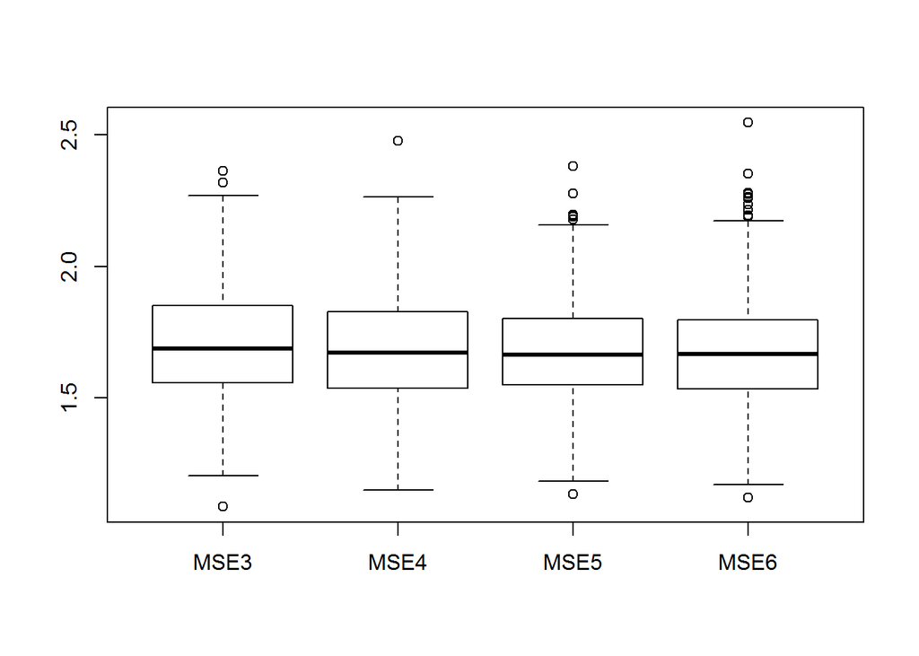

Let’s try now with Principal component regression and partial least squares

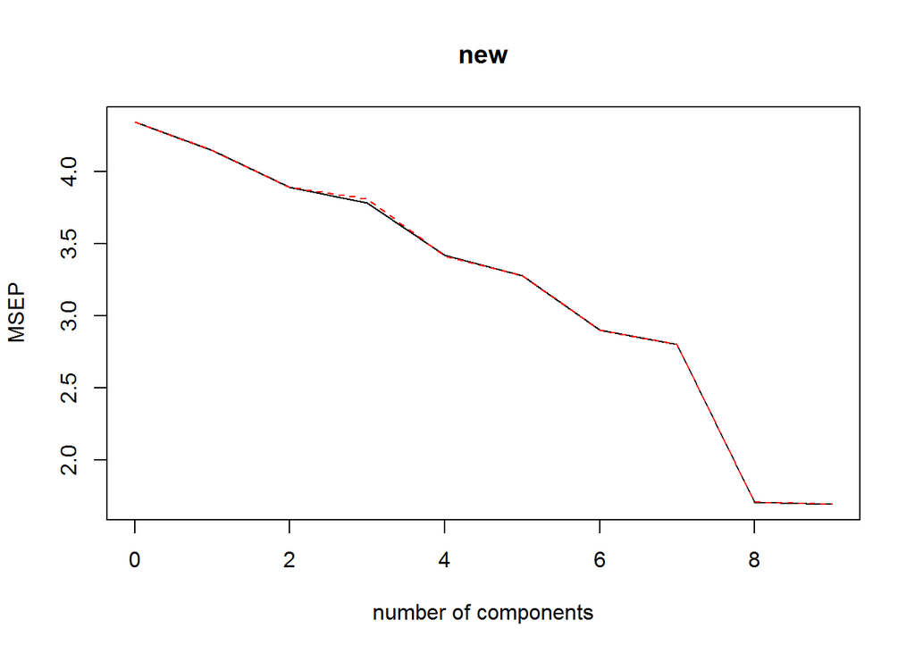

```r
#install.packages("pls")
library(pls)
#PCR
#PRINCIPAL COMPONENT REGRESSION 1
set.seed(2)
pcr.fit1 <- pcr(new ~ PLEC+grupa_wiek+woj+ZPP+DC, data = DC_ACT11, scale = TRUE, validation = "CV")
#summary(pcr.fit1)
validationplot(pcr.fit1, val.type = "MSEP")
```

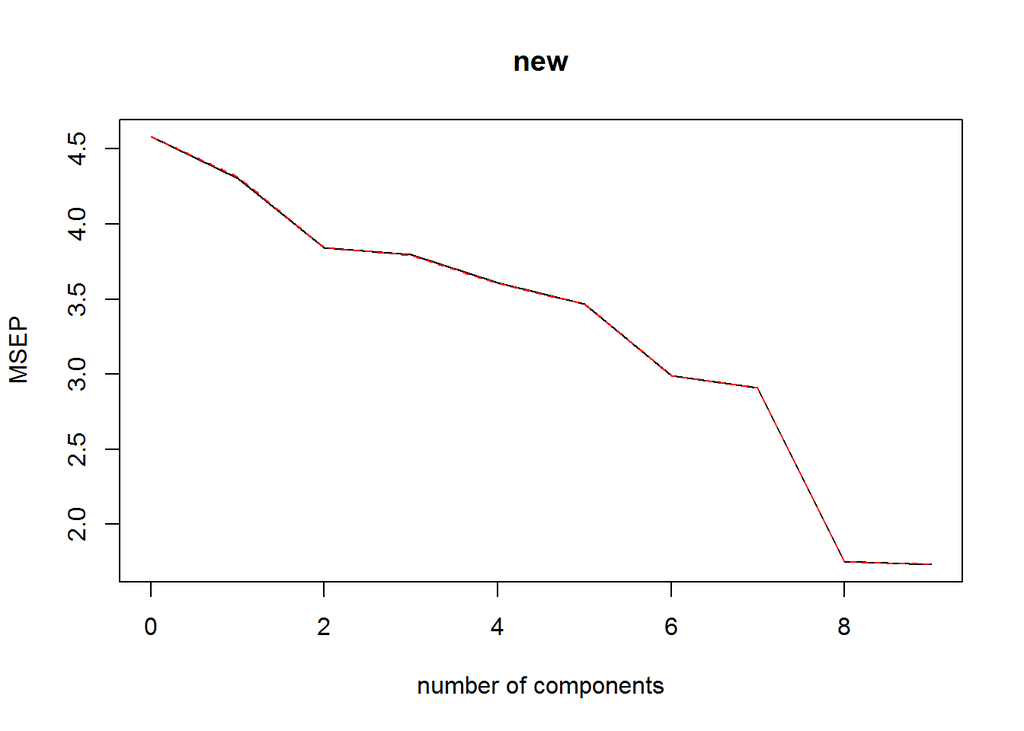

```r
set.seed(1)
train = sample(1:nrow(x_1), round(0.75*nrow(x_1)))
test <- -train
y.test <- y[test]
pcr.fit1 <- pcr(new ~ PLEC+grupa_wiek+woj+ZPP+DC, data = DC_ACT11, subset = train, scale = TRUE, validation = "CV")
#summary(pcr.fit1)
validationplot(pcr.fit1, val.type = "MSEP")
```

```r
pcr.pred1 = predict(pcr.fit1, x_1[test,])
mean((pcr.pred1-y.test)^2)
```

```
## [1] 1551.072
```

```r
pcr.fit1 <- pcr(new ~ PLEC+grupa_wiek+woj+ZPP+DC, data = DC_ACT11, scale = TRUE)
#summary(pcr.fit1)

#PRINCIPAL COMPONENT REGRESSION 2
set.seed(2)
pcr.fit2 <- pcr(new ~ PLEC+grupa_wiek+TERYT4+ZPP+DC, data = DC_ACT11, scale = TRUE, validation = "CV")
summary(pcr.fit2)
```

```
## Data:    X dimension: 6320 9
##  Y dimension: 6320 1
## Fit method: svdpc
## Number of components considered: 9
##
## VALIDATION: RMSEP
## Cross-validated using 10 random segments.
##        (Intercept)  1 comps  2 comps  3 comps  4 comps  5 comps  6 comps
## CV           2.083    2.033    1.966    1.934    1.853    1.829    1.705
## adjCV        2.083    2.034    1.966    1.941    1.853    1.829    1.705
##        7 comps  8 comps  9 comps
## CV       1.662    1.308    1.302
## adjCV    1.662    1.308    1.302
##
## TRAINING: % variance explained
##      1 comps  2 comps  3 comps  4 comps  5 comps  6 comps  7 comps
## X     14.430    28.13    41.54    54.87    66.95    78.07    88.57
## new    4.887    11.41    13.90    21.36    23.37    33.50    36.81
##      8 comps  9 comps
## X      97.18   100.00
## new    60.88    61.24
```

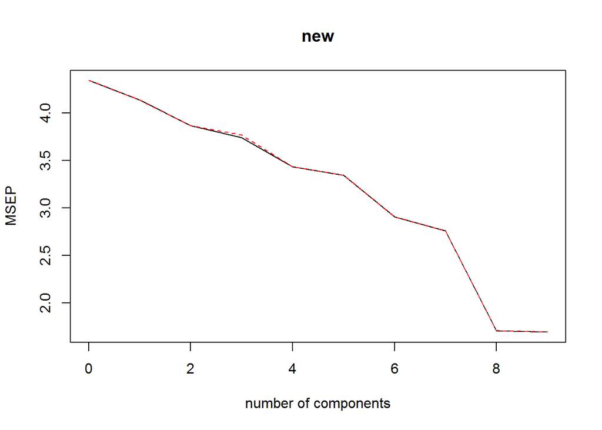

```r
validationplot(pcr.fit2, val.type = "MSEP")
```

```r
set.seed(1)
train = sample(1:nrow(x_2), round(0.75*nrow(x_2)))
test <- -train
y.test <- y[test]
pcr.fit2 <- pcr(new ~ PLEC+grupa_wiek+TERYT4+ZPP+DC, data = DC_ACT11, subset = train, scale = TRUE, validation = "CV")
summary(pcr.fit2)
```

```
## Data:    X dimension: 4740 9
##  Y dimension: 4740 1
## Fit method: svdpc
## Number of components considered: 9
##
## VALIDATION: RMSEP
## Cross-validated using 10 random segments.
##        (Intercept)  1 comps  2 comps  3 comps  4 comps  5 comps  6 comps
## CV            2.14    2.066    1.956    1.946    1.904    1.878    1.732
## adjCV         2.14    2.069    1.955    1.944    1.904    1.879    1.731
##        7 comps  8 comps  9 comps
## CV       1.693    1.323    1.317
## adjCV    1.693    1.323    1.316
##
## TRAINING: % variance explained
##      1 comps  2 comps  3 comps  4 comps  5 comps  6 comps  7 comps
## X     14.325    28.23    41.76    55.05    67.10    78.08    88.58
## new    6.398    16.70    17.72    21.33    23.47    35.09    37.89
##      8 comps  9 comps
## X      97.21   100.00
## new    62.37    62.75
```

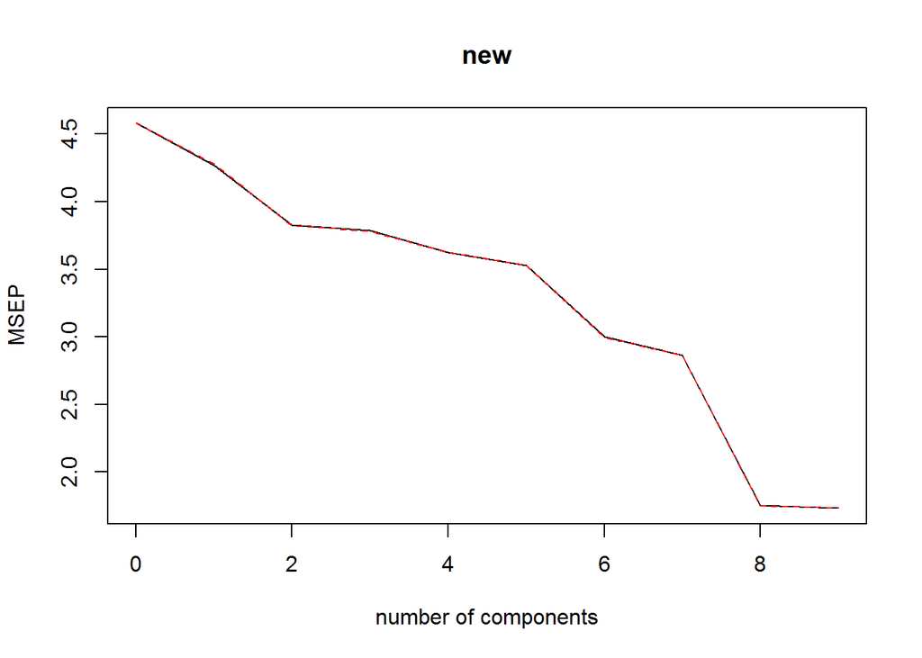

```r
validationplot(pcr.fit2, val.type = "MSEP")
```

```r
pcr.pred2 = predict(pcr.fit2, x_2[test,])
mean((pcr.pred2-y.test)^2)
```

```
## [1] 2.830095
```

```r
pcr.fit2 <- pcr(new ~ PLEC+grupa_wiek+TERYT4+ZPP+DC, data = DC_ACT11, scale = TRUE,)
summary(pcr.fit2)
```

```
## Data:    X dimension: 6320 9
##  Y dimension: 6320 1
## Fit method: svdpc
## Number of components considered: 9
## TRAINING: % variance explained
##      1 comps  2 comps  3 comps  4 comps  5 comps  6 comps  7 comps
## X     14.430    28.13    41.54    54.87    66.95    78.07    88.57
## new    4.887    11.41    13.90    21.36    23.37    33.50    36.81
##      8 comps  9 comps
## X      97.18   100.00
## new    60.88    61.24
```

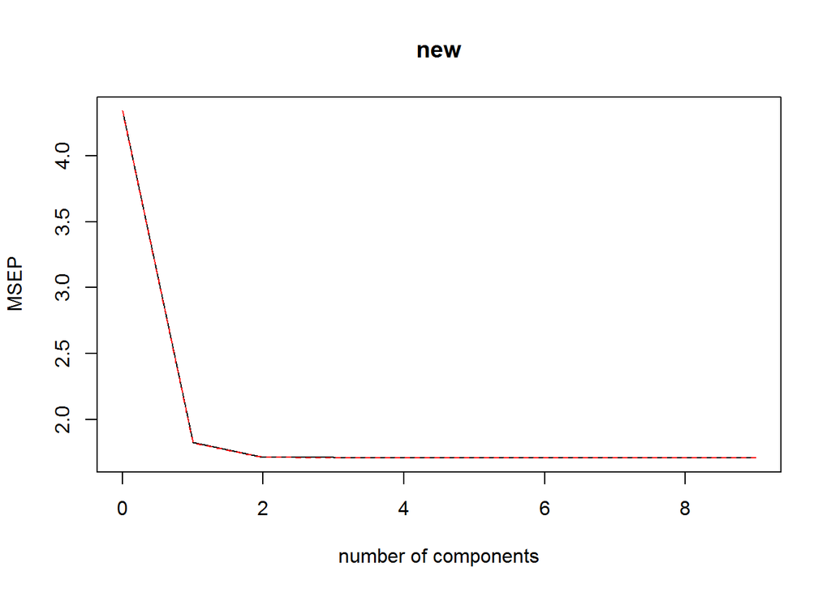

```r
#PARTIAL LEAST SQUARES 1
set.seed(1)
train = sample(1:nrow(x_1), round(0.75*nrow(x_1)))
test <- -train
y.test <- y[test]
pls.fit1 <- plsr(new ~ PLEC+grupa_wiek+woj+ZPP+DC, data = DC_ACT11, scale = TRUE, validation = "CV")
#summary(pls.fit1)
validationplot(pls.fit1, val.type = "MSEP")
```

```r
pls.pred1 <- predict(pls.fit1, x_1[test,])
mean((pls.pred1-y.test)^2)
```

```
## [1] 18.18427
```

```r
pls.fit1 <- plsr(new ~ PLEC+grupa_wiek+woj+ZPP+DC, data = DC_ACT11, scale = TRUE)
#summary(pls.fit1)

#PARTIAL LEAST SQUARES 2
set.seed(1)
train = sample(1:nrow(x_2), round(0.75*nrow(x_2)))
test <- -train
y.test <- y[test]
pls.fit2 <- plsr(new ~ PLEC+grupa_wiek+TERYT4+ZPP+DC, data = DC_ACT11, scale = TRUE, validation = "CV")
summary(pls.fit2)
```

```
## Data:    X dimension: 6320 9
##  Y dimension: 6320 1
## Fit method: kernelpls
## Number of components considered: 9
##
## VALIDATION: RMSEP
## Cross-validated using 10 random segments.
##        (Intercept)  1 comps  2 comps  3 comps  4 comps  5 comps  6 comps
## CV           2.083     1.35    1.310    1.308    1.307    1.307    1.307
## adjCV        2.083     1.35    1.309    1.308    1.307    1.307    1.307
##        7 comps  8 comps  9 comps
## CV       1.307    1.307    1.307
## adjCV    1.307    1.307    1.307
##
## TRAINING: % variance explained
##      1 comps  2 comps  3 comps  4 comps  5 comps  6 comps  7 comps
## X      11.90    22.71    33.12    38.93    50.25    62.00    74.23
## new    58.66    61.09    61.19    61.23    61.24    61.24    61.24
##      8 comps  9 comps
## X      86.60   100.00
## new    61.24    61.24
```

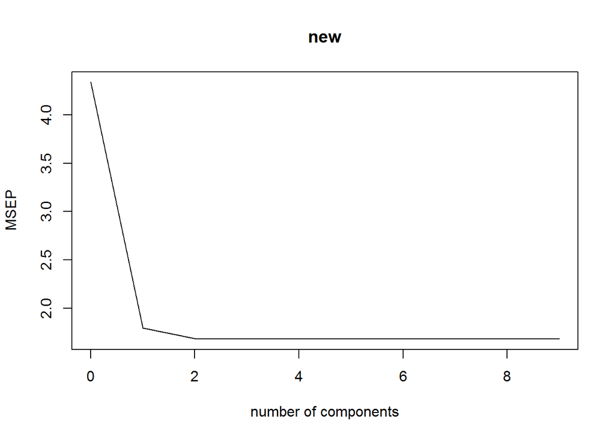

```r
validationplot(pls.fit1, val.type = "MSEP")
```

```r
pls.pred2 <- predict(pls.fit2, x_2[test,], ncomp=6)
mean((pls.pred2-y.test)^2)
```

```
## [1] 1.60807
```

```r
pls.fit2 <- plsr(new ~ PLEC+grupa_wiek+TERYT4+ZPP+DC, data = DC_ACT11, scale = TRUE, ncomp=6)
summary(pls.fit2)
```

```
## Data:    X dimension: 6320 9
##  Y dimension: 6320 1
## Fit method: kernelpls
## Number of components considered: 6
## TRAINING: % variance explained
##      1 comps  2 comps  3 comps  4 comps  5 comps  6 comps
## X      11.90    22.71    33.12    38.93    50.25    62.00
## new    58.66    61.09    61.19    61.23    61.24    61.24
```

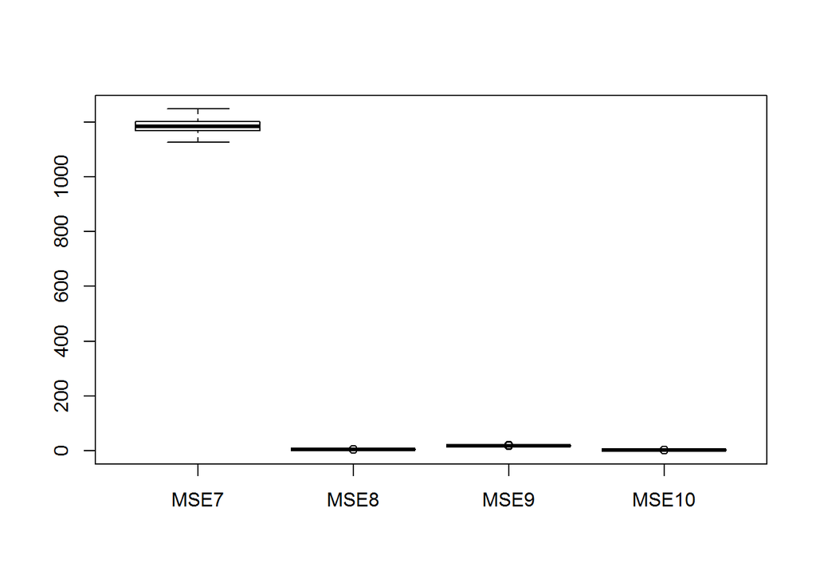

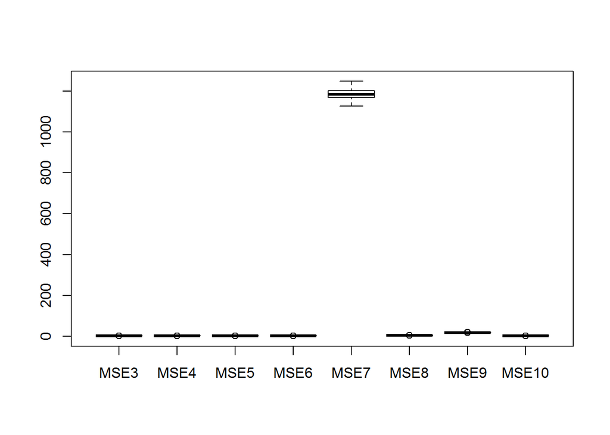

```
##
##  Two-sample Kolmogorov-Smirnov test
##
## data:  MSE5 and MSE6
## D = 0.038, p-value = 0.4658
## alternative hypothesis: two-sided
```

# Regression trees

```r
#install.packages("tree")
library(tree)
#TREE
set.seed(1)
train <-sample(1:nrow(x_2), round(0.75*nrow(x_2)))
tree.2 <- tree(new ~ PLEC+grupa_wiek+TERYT4+ZPP+DC, data = DC_ACT11, subset = train)
summary(tree.2)
```

```
##
## Regression tree:
## tree(formula = new ~ PLEC + grupa_wiek + TERYT4 + ZPP + DC, data = DC_ACT11,
##     subset = train)
## Variables actually used in tree construction:
## [1] "DC"         "grupa_wiek" "TERYT4"
## Number of terminal nodes:  8
## Residual mean deviance:  1.413 = 6686 / 4732
## Distribution of residuals:
##    Min. 1st Qu.  Median    Mean 3rd Qu.    Max.
##  -9.400  -0.481  -0.481   0.000   0.519  13.100
```

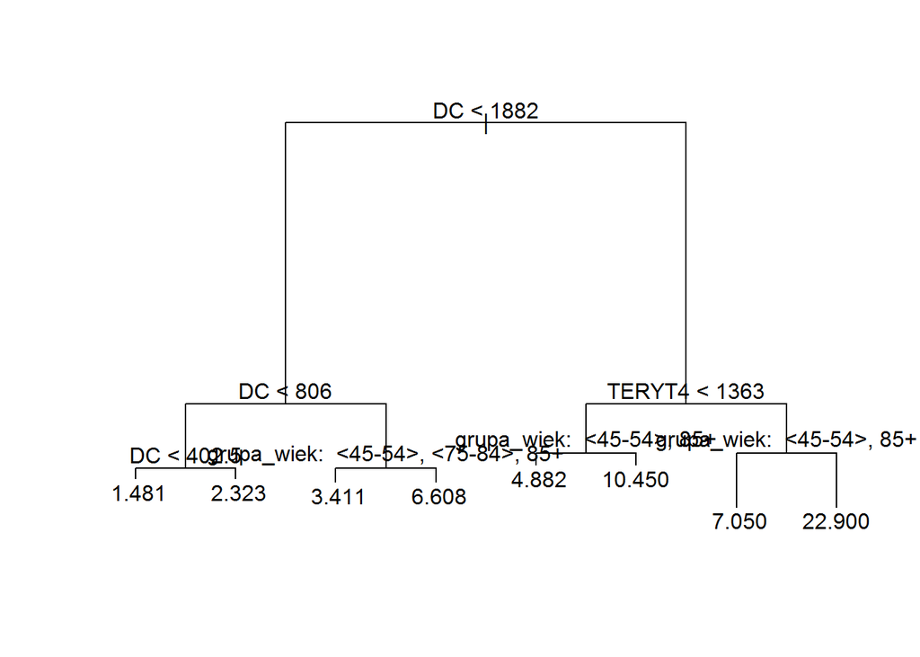

```r
plot(tree.2)
text(tree.2, pretty = 0)
```

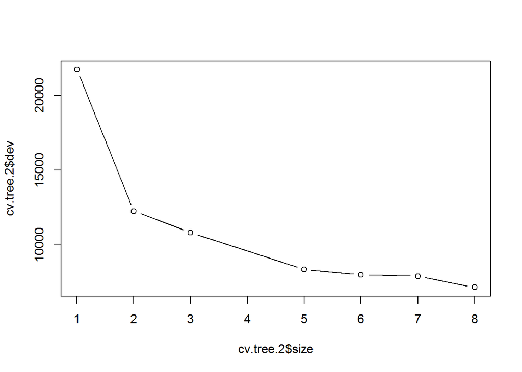

```r
cv.tree.2 <- cv.tree(tree.2)
plot(cv.tree.2$size, cv.tree.2$dev, type = "b")
```

```r
yhat <- as.data.frame(predict(tree.2, newdata = DC_ACT11[-train,]))
y.test <- DC_ACT11[-train, "new"]
mean((yhat-y.test)^2)
```

```
## [1] 1.82142
```

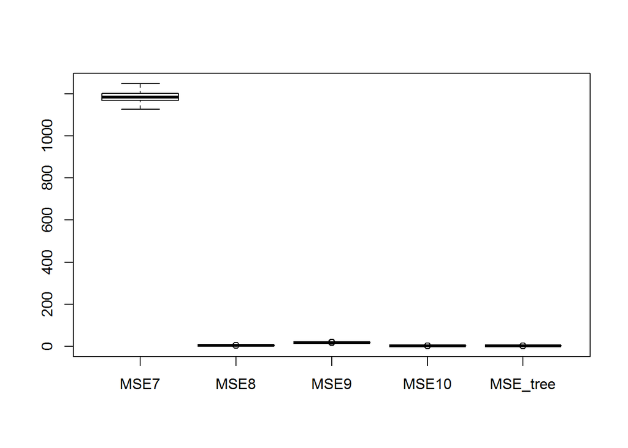

```r
MSE_tree <- c()
for (i in 1:1000){
    train <-sample(1:nrow(x_2), round(0.75*nrow(x_2)))
    test <- -train
    y.test <- DC_ACT11[-train, "new"]
    yhat <- predict(tree.2, newdata = DC_ACT11[-train,])
    MSE_tree[i] <- mean((yhat-y.test)^2)
}
boxplot(cbind(MSE7, MSE8, MSE9, MSE10, MSE_tree))
```

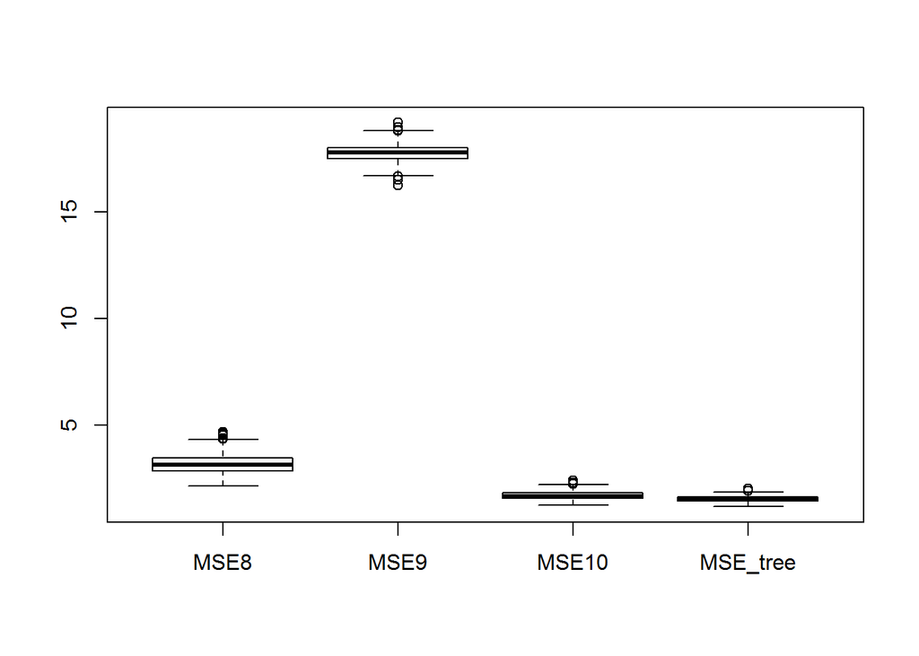

```r
boxplot(cbind(MSE8, MSE9, MSE10, MSE_tree))
```

# Random Forest

```r
library(randomForest)
bag.2 <- randomForest(new ~ PLEC+grupa_wiek+TERYT4+ZPP+DC, data = DC_ACT11, subset = train, mtry = 4, importance = TRUE)
bag.2
```

```
##
## Call:
##  randomForest(formula = new ~ PLEC + grupa_wiek + TERYT4 + ZPP +      DC, data = DC_ACT11, mtry = 4, importance = TRUE, subset = train)
##                Type of random forest: regression
##                      Number of trees: 500
## No. of variables tried at each split: 4
##
##           Mean of squared residuals: 1.408707
##                     % Var explained: 68.48
```

```r
importance(bag.2)
```

```
##              %IncMSE IncNodePurity
## PLEC        4.944033      610.5353
## grupa_wiek 56.446001     3415.6383
## TERYT4     12.083295     1050.0382
## ZPP        11.985481     1734.3807
## DC         85.593683    13129.8377
```

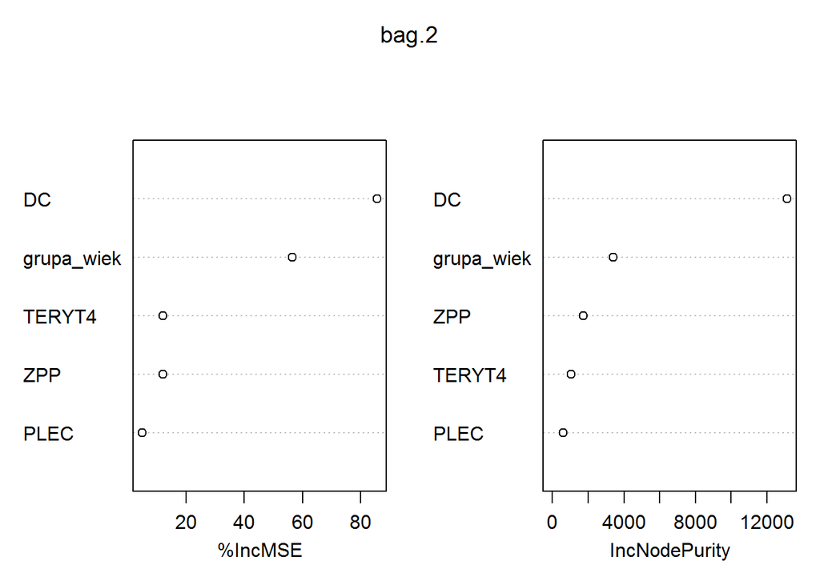

```r
varImpPlot(bag.2)
```

```r
yhat.bag <- predict(bag.2, newdata = DC_ACT11[-train,])
mean((yhat.bag-y.test)^2)
```

```
## [1] 1.382997
```

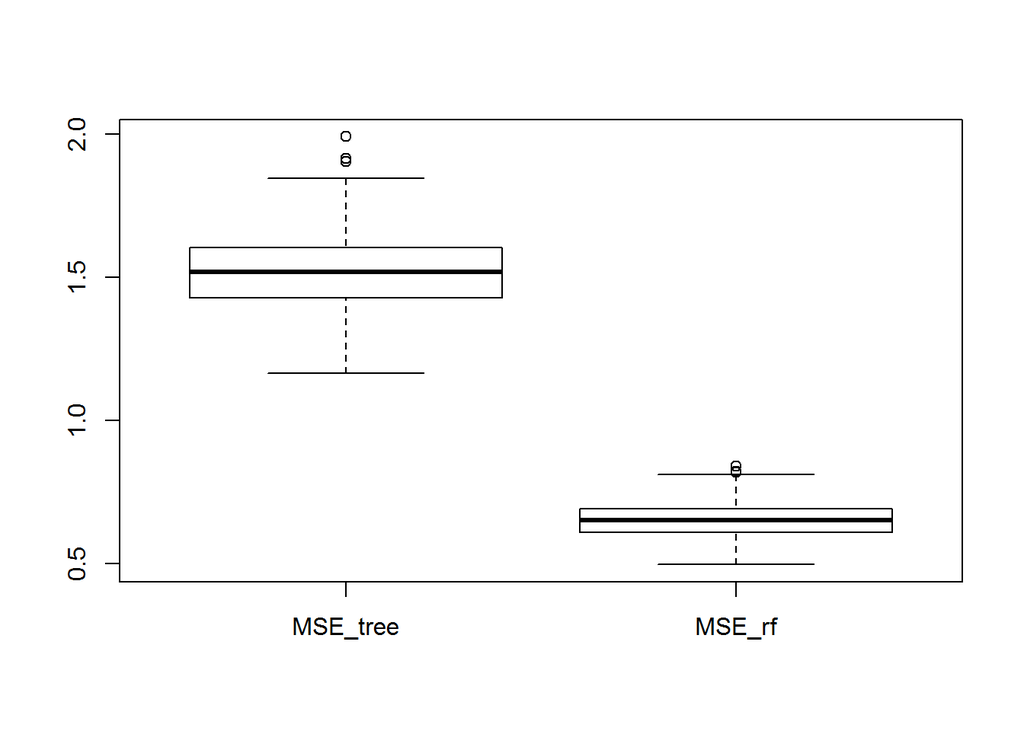

```r
MSE_rf <- c()
for (i in 1:1000){
    train <-sample(1:nrow(x_2), round(0.75*nrow(x_2)))
    test <- -train
    y.test <- DC_ACT11[-train, "new"]
    yhat.bag <- predict(bag.2, newdata = DC_ACT11[-train,])
    MSE_rf[i] <- mean((yhat.bag-y.test)^2)
}
boxplot(cbind(MSE_tree, MSE_rf))
```

# Boosting

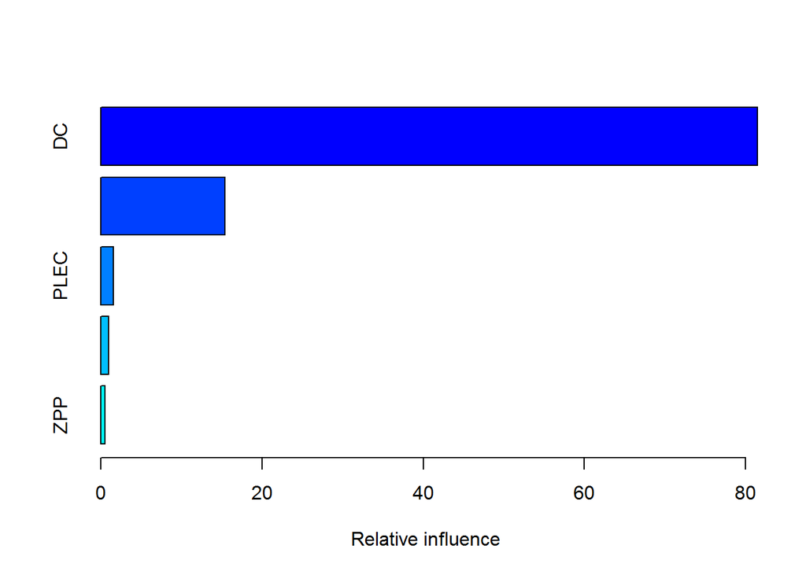

```
##                   var    rel.inf
## DC                 DC 81.4554267
## grupa_wiek grupa_wiek 15.4356694
## PLEC             PLEC  1.6016432
## TERYT4         TERYT4  0.9559940
## ZPP               ZPP  0.5512667
```

```r
#install.packages("gbm")
library(gbm)
set.seed(1)
boost.2 <- gbm(new ~ PLEC+grupa_wiek+TERYT4+ZPP+DC, data = DC_ACT11[train,], distribution = "gaussian", n.trees = 5000, interaction.depth = 4)
summary(boost.2)
```

```r
yhat.boost <- predict(boost.2, newdata = DC_ACT11[-train,], n.trees = 5000)
mean((yhat.boost-y.test)^2)
```

```
## [1] 1.371338
```

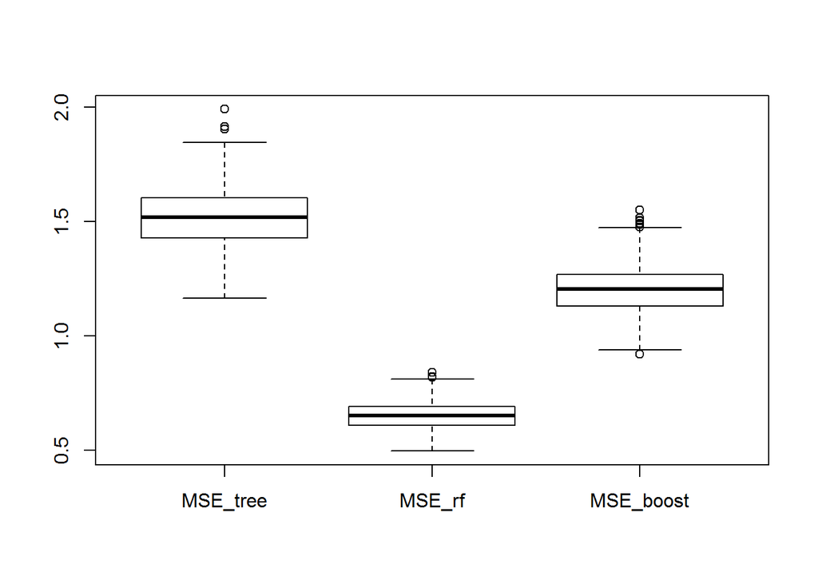

```r
MSE_boost <- c()
for (i in 1:1000){
    train <-sample(1:nrow(x_2), round(0.75*nrow(x_2)))
    test <- -train
    y.test <- DC_ACT11[-train, "new"]
    yhat.boost <- predict(boost.2, newdata = DC_ACT11[-train,], n.trees = 5000)
    MSE_boost[i] <- mean((yhat.boost-y.test)^2)
}
boxplot(cbind(MSE_tree, MSE_rf, MSE_boost))
```

```r
#boxplot(cbind(MSE1, MSE7, MSE_tree, MSE_rf, MSE_boost))
```

# Conclusion

The best model is:

```r
bag.2 <- randomForest(new ~ PLEC+grupa_wiek+TERYT4+ZPP+DC, data = DC_ACT11, subset = train, mtry = 4, importance = TRUE)
bag.2
```

```
##
## Call:
##  randomForest(formula = new ~ PLEC + grupa_wiek + TERYT4 + ZPP +      DC, data = DC_ACT11, mtry = 4, importance = TRUE, subset = train)
##                Type of random forest: regression
##                      Number of trees: 500
## No. of variables tried at each split: 4
##
##           Mean of squared residuals: 1.411399
##                     % Var explained: 66.77
```

## Data preparation

```r
dt<- read.csv2("dane_podstawowe_ICD.csv")


row_delete_M <- which((dt$ICD10== "C53"|dt$ICD10== "C54"| dt$ICD10=="C56") & (dt$PLEC=="M"))
dt1<-dt[-row_delete_M,]
row_delete_K <- which((dt1$ICD10== "C61"|dt1$ICD10== "C62") & (dt1$PLEC=="K"))
dt2<-dt1[-row_delete_K,]

library("PogromcyDanych")
dt3<- dt2 %>%
  group_by(ICD10, PLEC, grupa_wiek, TERYT4, woj, pow, rok) %>%
    summarise(Stage1 = sum(Stage1),
            Stage2 = sum(Stage2),
            Stage3 = sum(Stage3),
            Stage4 = sum(Stage4))

dt3$new<-dt3$Stage1 +dt3$Stage2 +dt3$Stage3 +dt3$Stage4

dt3$CancerGroup<-1

HandN <- which(dt3$ICD10== "C00"|dt3$ICD10== "C01_C02_C03_C04_C05_C06_C09_C10_C14"|
                  dt3$ICD10=="C07_C08" |dt3$ICD10=="C11_C12_C13_C30_C31")
dt3[HandN,]$CancerGroup<-"Malignant neoplasms of head and neck cancer"

deOrg <- which(dt3$ICD10== "C15"|dt3$ICD10== "C16_C26"| dt3$ICD10== "C25"|
                 dt3$ICD10=="C20_C21" |dt3$ICD10=="C22" |dt3$ICD10=="C23_C24" |dt3$ICD10== "C18_C19")
dt3[deOrg,]$CancerGroup<-"Malignant neoplasms of digestive organs"

RandI <- which(dt3$ICD10== "C32"|dt3$ICD10== "C33_C34"| dt3$ICD10== "C43")
dt3[RandI,]$CancerGroup<-"Malignant neoplasms of respiratory and intrathoracic organs"

NofB <- which(dt3$ICD10== "C50_D05")
dt3[NofB,]$CancerGroup<-"Malignant neoplasm of breast"

FGO <- which(dt3$ICD10== "C53"|dt3$ICD10== "C54"| dt3$ICD10== "C56")
dt3[FGO,]$CancerGroup<-"Malignant neoplasms of female genital organs"

MGO <- which(dt3$ICD10== "C61"|dt3$ICD10== "C62")
dt3[MGO,]$CancerGroup<-"Malignant neoplasms of male genital organs"

NofUT <- which(dt3$ICD10== "C64_C65_C66"|dt3$ICD10== "C67")
dt3[NofUT,]$CancerGroup<-"Malignant neoplasms of urinary tract"

CNS <- which(dt3$ICD10== "C70_C71_C72")
dt3[CNS,]$CancerGroup<-"Malignant neoplasms of eye, brain and other parts of central nervous system"

TG <- which(dt3$ICD10== "C73")
dt3[TG,]$CancerGroup<-"Malignant neoplasm of thyroid gland"

dt3$CancerSex<-"Both"

M <- which(dt3$CancerGroup== "Malignant neoplasms of male genital organs")
dt3[M,]$CancerSex<-"Men"

K <- which(dt3$CancerGroup== "Malignant neoplasms of female genital organs")
dt3[K,]$CancerSex<-"Female"

dt_ACT<-as.data.frame(dt3)

save(dt_ACT,file="dataCancer.Rda")

DT_ACT<-load("dataCancer.Rda")
```